# Summary

With robots working in greater proximity to humans than before, they must have advanced sensing capabilities to recognize and avoid potential collisions to minimize risk of injury. Customers are using TI’s industrial mmWave sensors to enable not only distance measurement but also relative velocities of people in the scene that can be used to trigger robot slow down or stop depending on proximity and speed of approach. TI mmWave radar brings additional value over vision and LiDAR based sensors by seeing in challenging environments such as rain, smoke, poor lighting and dusty factory conditions.

Key sensing challenges that Radar can address in **Autonomous Ground Vehicle(AGV)** and **Autonomous Mobile Robot(AMR)** applications:

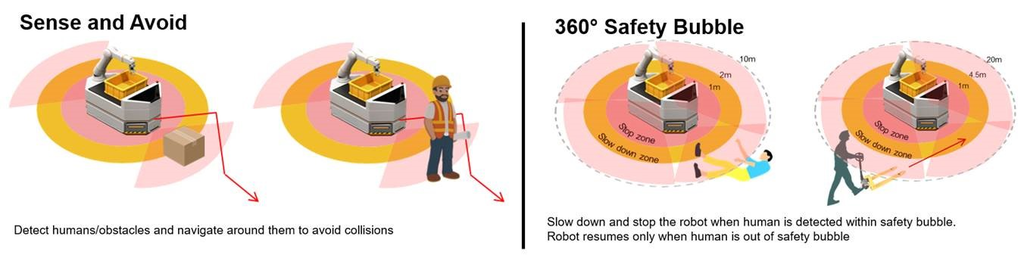

# TI’s Offering

What can TI’s IWR6843/IWR6843AOP mmWave radar sensors offer for AGV/AMRs?

1. **3D obstacle detection and tracking** for path planning and autonomous navigation while enabling **fast update rate (10’s of fps)** and **wide azimuth area coverage up to 130 degrees**
2. **IEC 61508 SIL 2 certified** to enable replacement of expensive safety certified LiDAR sensors for **safe human presence detection**
3. **Increased angular resolution** with **imaging radar** provides the ability to detect boundaries and navigate more accurately in busy environments
4. Enable **reliable detection of glass walls/doors** over other sensing technologies like vision/LiDAR that “sees” through them
5. **Highly integrated offering** including everything from radar front-end, antenna built-in MCU and simple SPI interface to report static and moving obstacles in the path of the AGV, all fitting in a 15x15 mm2 component
6. A broad portfolio of 15+ options in **60GHz and 77GHz frequency bands offering feature scalability** and ease of deployment in different regions to closely match your needs

# Getting Started

Get started today with mmWave for AGV/AMR’s!

## Featured Demonstration Videos:

Video Topic

Preview

[**Sense and Avoid**](https://training.ti.com/robotics-using-mmwave) for obstacle detection and navigation

[video not shown]

[**360 Degree Safety Bubble**](https://training.ti.com/safer-robots-using-rectangular-safety-bubbles) for surround view human presence detection and collision avoidance

[video not shown]

## Development Resources:

- TI Radar ROS Driver
- Sense and Avoid Lab with ROS
- Safety Bubble Lab with ROS
- Static and dynamic obstacle tracking on a mobile platform
- Radar and LIDAR comparison
- Cliff Detection using radar

## Certification

- [TI mmWave Radar Device Regulatory Compliance Guide](http://www.ti.com/lit/spracp3)
- TI mmWave Certification Database

## Recommend Devices

- IWR6843 - 4Rx3Tx 60GHz mmWave radar sensor w/ DSP & HWA (production)
  - Check out the IWR6843ISK evaluation module to get started
- IWR6843AOP – IWR6843 with integrated antenna on the package (production)
  - Check out the IWR6843AOPEVM evaluation module to get started

## Functional Safety Resources

- [Understanding Functional Safety in Automotive and Industrial Applications](https://e2e.ti.com/blogs_/b/process/posts/understanding-the-importance-of-functional-safety-in-automotive-and-industrial-sensing-applications)
- [TI mmWave Functional Safety Enablers](http://www.ti.com/lit/sprt747)

# Third Party Resources

- [Designing TI mmWave radar made easier using our third-party ecosystem](https://e2e.ti.com/blogs_/b/industrial_strength/posts/ti-mmwave-radar-made-easy-with-our-third-party-ecosystem)
- [Browse third-party solutions and find the right third-party to meet your needs](https://www.ti.com/tool/MMWAVE-3P-SEARCH)

Third Party

Video Topic

Preview

[**D3 Engineering**](https://www.d3engineering.com/)

[**Multi-sensor, smarter and safer autonomous mobile robots with real-time control demo**](https://training.ti.com/multi-sensor-smarter-and-safer-autonomous-mobile-robots-real-time-control-demo)

[video not shown]

[**Oculii**](https://www.oculii.com/)

[**Autonomous robotics using TI mmWave sensors**](https://training.ti.com/autonomous-robotics-using-ti-mmwave-sensors)

[video not shown]

[**Oculii**](https://www.oculii.com/)

[**Imaging radar-based SLAM for autonomous mobile robots**](https://training.ti.com/imaging-radar-based-slam-autonomous-mobile-robots)

[video not shown]

# Need more information?

- Visit the Industrial mmWave Radar Sensor portal at [ti.com/iwr](https://www.ti.com/sensors/mmwave-radar/industrial/overview.html)
- Search for your question or post a new question on the [mmWave E2E forum](https://e2e.ti.com/support/sensor/mmwave_sensors/f/1023)